# Optimal Systolic Blood Pressure Target in Resistant and Non-Resistant Hypertension: A Pooled Analysis of Patient-Level Data from SPRINT and ACCORD - ScienceDirect

## Cited By (14)

## Figures (11)

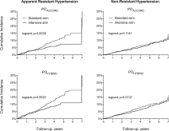

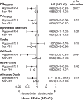

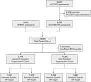

## [The American Journal of Medicine](https://www.sciencedirect.com/journal/the-american-journal-of-medicine)

[Volume 131, Issue 12](https://www.sciencedirect.com/journal/the-american-journal-of-medicine/vol/131/issue/12), December 2018, Pages 1463-1472.e7

# Clinical Research Study Optimal Systolic Blood Pressure Target in Resistant and Non-Resistant Hypertension: A Pooled Analysis of Patient-Level Data from SPRINT and ACCORD

https://doi.org/10.1016/j.amjmed.2018.08.005[Get rights and content](https://s100.copyright.com/AppDispatchServlet?publisherName=ELS&contentID=S0002934318307836&orderBeanReset=true)

## Abstract

### Background

Prior studies suggest benefits of blood pressure lowering on cardiovascular risk may be attenuated in patients with [resistant hypertension](https://www.sciencedirect.com/topics/nursing-and-health-professions/resistant-hypertension) compared with the general hypertensive population, but prospective data are lacking.

### Methods

We assessed intensive (<120 mm Hg) versus standard (<140 mm Hg) [systolic blood pressure](https://www.sciencedirect.com/topics/nursing-and-health-professions/systolic-blood-pressure) targets on [adverse outcome](https://www.sciencedirect.com/topics/medicine-and-dentistry/adverse-outcome) risk according to baseline resistant hypertension status, using Action to Control Cardiovascular Risk in Diabetes (ACCORD) and Systolic Blood Pressure Intervention Trial (SPRINT) patient-level data. Patients were categorized as having baseline apparent resistant hypertension (blood pressure ≥130/80 mm Hg while using 3 [antihypertensive drugs](https://www.sciencedirect.com/topics/medicine-and-dentistry/antihypertensive-agent) or use of ≥4 drugs regardless of blood pressure) or non-resistant hypertension (all others). [Cox regression](https://www.sciencedirect.com/topics/nursing-and-health-professions/proportional-hazards-model) was used to assess effects of treatment assignment, resistant hypertension status, their interaction, and other covariates, on first occurrence of 2 outcomes: myocardial infarction, stroke, cardiovascular death ± heart failure, and the same outcomes plus all-cause death, individually.

### Results

Among 14,094 patients, 2710 (19.2%) had baseline apparent resistant hypertension. In adjusted models, an intensive target reduced risk of both outcomes (myocardial infarction/stroke/cardiovascular death: hazard ratio [HR], 0.81; 95% confidence interval [CI], 0.71-0.93; myocardial infarction/stroke/heart failure/cardiovascular death: HR 0.78; 95% CI, 0.69-0.88) as well as stroke (HR 0.72; 95% CI, 0.55-0.94) and heart failure (HR 0.73; 95% CI, 0.59-0.91). An intensive target also appeared to reduce myocardial infarction, cardiovascular death, and all-cause death risk. Benefits were observed irrespective of baseline resistant hypertension status.

### Conclusions

Our findings provide the first evidence to support guidance to treat resistant hypertension to the same blood pressure goal as non-resistant hypertension.

## Keywords

ACCORD

Antihypertensive agents

Blood pressure

Hypertension

Resistant hypertension

SPRINT

Over 1 billion individuals worldwide have hypertension, the leading reversible risk factor for major adverse cardiovascular outcomes and death.1, 2 Of these individuals, 10% to 20% are thought to have resistant hypertension, a high-risk phenotype defined by uncontrolled blood pressure despite treatment with ≥3 antihypertensive drugs, or need for ≥4 antihypertensive drugs regardless of blood pressure.<sup>3</sup> Prior studies, defining uncontrolled blood pressure as ≥140/90 mm Hg, have consistently documented excess risk of adverse cardiovascular outcomes and death,4, 5, 6, 7, 8, 9, 10 and impaired quality of life,11, 12 comparing resistant versus non-resistant hypertension.

Although management of the general hypertensive population has been extensively studied, remarkably little evidence guides treatment in resistant hypertension. In particular, prospective studies are lacking on the most appropriate blood pressure target in this population. Absent such data, recommendations for the general hypertensive population are extrapolated to resistant hypertension.<sup>13</sup> However, empiric evidence suggests that benefits of blood pressure lowering on cardiovascular outcomes in the general population may not extend fully to resistant hypertension.4, 5<sup>,</sup>10, 14<sup>,</sup><sup>15</sup> For example, prior studies have observed no difference in outcomes comparing controlled (blood pressure <140/90 mm Hg) with uncontrolled resistant hypertension,<sup>5</sup> that achieving blood pressure <140/90 mm Hg reduces cardiovascular risk by half as much in resistant hypertension compared to non-resistant hypertension,<sup>14</sup> and that greater blood pressure control portends worse renal outcomes in resistant versus non-resistant hypertension.<sup>15</sup> Additionally, more intensive therapy is associated with greater rates of cardiovascular events<sup>4</sup> and lower quality of life<sup>12</sup> in resistant hypertension. Nevertheless, all prior studies have examined the relationship between blood pressure and outcomes in observational cohorts, or randomized controlled trials treated as observational cohorts, and it remains unclear to what extent these findings impact patient care.

Therefore, we investigated the relationship between resistant hypertension, systolic blood pressure target, and [adverse outcomes](https://www.sciencedirect.com/topics/medicine-and-dentistry/adverse-outcome), pooling patient-level data from the Systolic Blood Pressure Intervention Trial (SPRINT)<sup>16</sup> and Action to Control Cardiovascular Risk in Diabetes (ACCORD) trial,<sup>17</sup> both of which prospectively tested intensive (<120 mm Hg) versus standard (<140 mm Hg) systolic blood pressure targets among diverse high-risk hypertensive populations. We hypothesized that intensive systolic blood pressure lowering would confer similar benefits on cardiovascular outcomes and death in resistant and non-resistant hypertension.

CLINICAL SIGNIFICANCE

• Data regarding the optimal blood pressure target in treatment-resistant hypertension are sparse and inconsistent, and current recommendations are extrapolated from the general hypertensive population.

•Among 14,094 SPRINT and ACCORD-BP participants, 19.2% had baseline apparent treatment-resistant hypertension using the revised 2017 hypertension guideline definition.

• A systolic blood pressure target <120 mm Hg, compared to a target <140 mm Hg, reduced risk of most major cardiovascular outcomes and death, irrespective of baseline treatment-resistant hypertension status.

## Methods

The design and principal findings of [SPRINT](https://www.sciencedirect.com/topics/nursing-and-health-professions/systolic-blood-pressure)16, 18 and the ACCORD blood pressure trial (ACCORD-BP)17, 19 are published. Briefly, SPRINT was a prospective, randomized, open-label, blinded-endpoint (PROBE) trial enrolling 9361 hypertensive individuals with elevated cardiovascular risk, but without diabetes or stroke. Participants were assigned to a target systolic blood pressure <120 mm Hg (“intensive”) or <140 mm Hg (“standard”). They were aged ≥50 years, with hypertension and ≥1 additional cardiovascular risk factor. SPRINT follow-up was terminated early due to a clear benefit with the intensive systolic BP target.<sup>16</sup> ACCORD was also a PROBE-design trial enrolling 10,251 high-risk individuals with diabetes from the United States and Canada. The design included a 2 × 2 factorial to assess [glycemic control](https://www.sciencedirect.com/topics/medicine-and-dentistry/glycemic-control) in all participants and of these, 4733 were simultaneously enrolled in ACCORD-BP, testing the same blood pressure targets used in SPRINT. Major inclusion criteria were type 2 diabetes mellitus and age ≥40 years with cardiovascular disease or ≥55 years without cardiovascular disease. The Supplement (available online) contains additional eligibility criteria for both trials.

### Cohort Assembly

Patient-level data were acquired from the National Heart, Lung, and Blood Institute pursuant to a data use agreement after institutional review board approval. Complete ACCORD-BP data were available, whereas only data presented in the primary outcome paper<sup>16</sup> were available from SPRINT, including baseline measures, follow-up blood pressure and [antihypertensive](https://www.sciencedirect.com/topics/medicine-and-dentistry/antihypertensive-agent) use (number only, not specific drugs/classes), and outcomes.

Prior to pooling both trials, we tested study by treatment assignment interactions for all outcomes to assess heterogeneity. Thereafter, data were pooled and harmonized. Because the available data from SPRINT did not include information on specific drug use, dosing, or adherence, we categorized patients as having apparent [resistant hypertension](https://www.sciencedirect.com/topics/nursing-and-health-professions/resistant-hypertension) (denoting an inability to exclude pseudoresistance) or non-resistant hypertension at baseline. Apparent resistant hypertension was defined per prevailing guidelines<sup>13</sup> as using ≥3 antihypertensive drugs with blood pressure ≥130 mm Hg systolic or ≥80 mm Hg diastolic, or use of ≥4 antihypertensives regardless of blood pressure. For both trials, blood pressures represented the average of 3 clinic measurements via automated Omron 907 monitors (Omron Healthcare, Kyoto, Japan) with patients seated after 5 minutes of quiet rest. Patients not meeting apparent resistant hypertension criteria were considered to have non-resistant hypertension.

To assess possible influence of misclassifying pseudoresistant hypertension as resistant hypertension, we also performed sensitivity analyses by categorizing resistant hypertension status at the 6-month visit (or immediate prior visit if 6-month data were unavailable) rather than the baseline visit, under the assumption that in-trial [blood pressure measurement](https://www.sciencedirect.com/topics/nursing-and-health-professions/blood-pressure-measurement) and antihypertensive medication prescribing would have greater standardization per study protocols and that patients would have greater in-trial adherence. Patients with an event before the 6-month visit were excluded from these analyses.

### Outcomes

The SPRINT primary outcome was first occurrence of nonfatal myocardial infarction, nonfatal stroke, cardiovascular death, heart failure, or [acute coronary syndrome](https://www.sciencedirect.com/topics/nursing-and-health-professions/acute-coronary-syndrome), whereas the ACCORD-BP primary outcome was first occurrence of nonfatal myocardial infarction, nonfatal stroke, or cardiovascular death; heart failure was a secondary outcome and acute coronary syndrome was not. Therefore, we created 2 composite measures for all patients using data available in both datasets: the ACCORD-BP primary outcome (PO<sub>ACCORD</sub>) and a hybrid primary outcome defined as first occurrence of myocardial infarction, stroke, heart failure, or cardiovascular death (PO<sub>hybrid</sub>). We also assessed individual outcomes of myocardial infarction, stroke, heart failure, cardiovascular death, and all-cause death.

### Statistical Analysis

Baseline characteristics were summarized by hypertension status and treatment assignment, with between-treatment comparisons (intensive vs standard) performed using student *t* tests and chi-squared test. Cumulative incidence curves were created for each outcome, comparing intensive vs standard arms, by hypertension status. Cox [proportional hazards models](https://www.sciencedirect.com/topics/nursing-and-health-professions/proportional-hazards-model) were fit for each outcome in 2 stages: 1) simple models testing treatment assignment, hypertension status (apparent resistant vs non-resistant hypertension), and their interaction; and 2) full models for each outcome. Treatment assignment, hypertension status, and [study cohort](https://www.sciencedirect.com/topics/nursing-and-health-professions/cohort-analysis) (SPRINT vs ACCORD-BP; also, a proxy for no diabetes [SPRINT] or diabetes [ACCORD-BP]) were forced into all full models. We used stepwise selection (*P* < .2 for entry; *P* < .1 to remain), examining the following pre-determined covariates: age, sex, race/ethnicity, baseline [statin](https://www.sciencedirect.com/topics/nursing-and-health-professions/statin-protein) and aspirin use, clinical cardiovascular disease history, smoking status, baseline systolic and diastolic blood pressure, Framingham 10-year cardiovascular risk, baseline body mass index, [estimated glomerular filtration rate](https://www.sciencedirect.com/topics/nursing-and-health-professions/estimated-glomerular-filtration-rate) and glucose, and assignment to the intensive [glycemia](https://www.sciencedirect.com/topics/nursing-and-health-professions/glucose-blood-level) vs standard glycemia arm (all SPRINT patients considered as receiving standard glycemia treatment). The proportional hazards assumption was confirmed for treatment assignment and hypertension status in all models. Analyses were performed using SAS 9.4 (SAS Institute, Cary, NC).